# Australian housing

Arindam Baruah

2023-06-13

```r
library(tidyverse)
library(naniar)
library(bookdown)
library(stringr)
library(stringi)
library(lubridate)
library(DT)
library(forcats)
library(ggthemes)
library(ggpubr)
library(corrplot)
library(mltools)
library(data.table)
```

# 1 Checking the data quality

One of the first steps we need to perform is to analyse the quality of the dataset.

First, we read in the dataset

```r
df_oz <- read_csv("data/RealEstateAU_1000_Samples.csv")
head(df_oz)
```

```
## # A tibble: 6 × 27
##   index     TID breadcrumb   category_name property_type building_size land_size
##   <dbl>   <dbl> <chr>        <chr>         <chr>         <chr>         <chr>
## 1     0 1350988 Buy>NT>DARW… Real Estate … House         <NA>          <NA>
## 2     1 1350989 Buy>NT>DARW… Real Estate … Apartment     171m²         <NA>
## 3     2 1350990 Buy>NT>DARW… Real Estate … Unit          <NA>          <NA>
## 4     3 1350991 Buy>NT>DARW… Real Estate … House         <NA>          <NA>
## 5     4 1350992 Buy>NT>DARW… Real Estate … Unit          201m²         <NA>
## 6     5 1350993 Buy>NT>DARW… Real Estate … Apartment     218m²         <NA>
## # ℹ 20 more variables: preferred_size <chr>, open_date <chr>,
## #   listing_agency <chr>, price <chr>, location_number <dbl>,
## #   location_type <chr>, location_name <chr>, address <chr>, address_1 <chr>,
## #   city <chr>, state <chr>, zip_code <dbl>, phone <chr>, latitude <lgl>,
## #   longitude <lgl>, product_depth <chr>, bedroom_count <dbl>,
## #   bathroom_count <dbl>, parking_count <dbl>, RunDate <dttm>
```

## 1.1 Check for null values

For this purpose, we check the presence of null values in each of the variables using a heatmap.

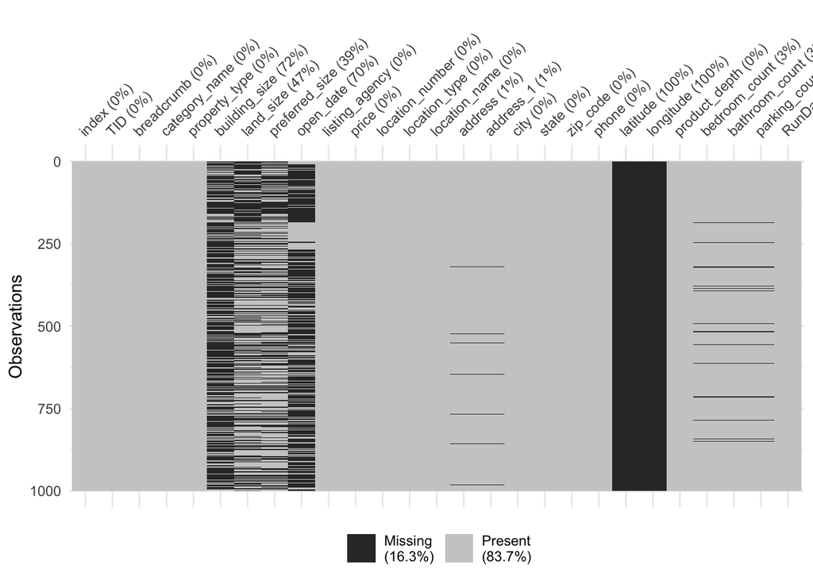

Figure 1.1: Heat map for null values

```r
vis_miss(df_oz)
```

As we can observe from figure 1.1,

- There are no values of latitude and longitude in the dataset. Hence, these variables can be dropped.
- There are fairly high number of missing values for the variables building size, land size, preferred size and open date. These will not be dropped but care must be taken while using these variables.
- Remaining variables have very low number of missing values. Hence, they can be used for our analysis without much concern.

# 2 Data cleaning

The next step is to clean the dataset and make it ready for analysis.

## 2.1 Feature selection

In this step, we will be retaining the important variables which could yield important results in our analysis. Variables falling under the following categories will be removed from the dataset:

- Variables which do not contribute any meaningful insights. (index, TID, breadcrumb,phone,product_depth)
- Variables with high number of null values. (latitude, longitude)
- Redundant columns which contain the same data. (Price and location_name variables contain the same data, which is the price of the property. Hence, location_name will be removed.)

```r
remove_variables <- c("index","TID","breadcrumb","phone","product_depth","latitude","longitude","location_name","address","RunDate","category_name","location_type")
df_oz_clean <- df_oz %>% select(-remove_variables)
```

## 2.2 Building land and preferrezed size

The various variables related to property and land sizes will be cleaned to cast them into numerical variable types.

```r
df_oz_clean$building_size <-as.numeric((gsub("([0-9]+).*$", "\\1", df_oz_clean$building_size)))
df_oz_clean$land_size <-as.numeric((gsub("([0-9]+).*$", "\\1", df_oz_clean$land_size)))
df_oz_clean$preferred_size <-as.numeric((gsub("([0-9]+).*$", "\\1", df_oz_clean$preferred_size)))
```

## 2.3 Price

The price variable will be converted to a numerical variable from the current character variable.

```r
df_oz_clean$price <-as.numeric(gsub("\\D", "", df_oz_clean$price))
```

## 2.4 Address

As the exact unit address does not provide us with any additional data, hence we shall simply retain the street address.

```r
df_oz_clean$address_1 <-as.character(gsub("[^a-zA-Z]", " ", df_oz_clean$address_1))
stop_words <- c("Lot","Unit","UNIT")
df_oz_clean$address_1 <- str_remove(df_oz_clean$address_1, "Lot")
df_oz_clean$address_1 <- str_remove(df_oz_clean$address_1, "UNIT")
df_oz_clean$address_1 <- str_remove(df_oz_clean$address_1, "Unit")
df_oz_clean$address_1 <- str_squish(df_oz_clean$address_1)

df_oz_clean <- df_oz_clean %>% rename( "street_address" =  "address_1")
```

## 2.5 Open date

```r
df_oz_clean$open_date <- if_else(df_oz_clean$open_date == "Added yesterday","1",df_oz_clean$open_date)
df_oz_clean$open_date <- if_else(str_detect(df_oz_clean$open_date,"hour"),"0",df_oz_clean$open_date)
df_oz_clean$open_date <-as.numeric(gsub("\\D", "", df_oz_clean$open_date))
df_oz_clean$open_date <- (ymd(20221029) - days(df_oz_clean$open_date))
```

## 2.6 Finalised clean data

Here is a glimpse of the dataset after the completion of all the data cleaning operations.

```r
df_oz_clean %>% DT::datatable()
```

|  | property_type | building_size | land_size | preferred_size | open_date | listing_agency | price | location_number | street_address | city | state | zip_code | bedroom_count | bathroom_count | parking_count |
| --- | --- | --- | --- | --- | --- | --- | --- | --- | --- | --- | --- | --- | --- | --- | --- |
| 1 | House |  |  |  | 2022-10-29 | Professionals - DARWIN CITY | 435000 | 139468611 | Woods Street | Darwin City | NT | 800 | 2 | 1 | 1 |
| 2 | Apartment | 171 |  | 171 | 2022-10-29 | Nick Mousellis Real Estate - Eview Group Member | 320000 | 139463755 | Dashwood Place | Darwin City | NT | 800 | 3 | 2 | 2 |
| 3 | Unit |  |  |  | 2022-10-29 | Habitat Real Estate - THE GARDENS | 310000 | 139462495 | Woods Street | Darwin City | NT | 800 | 2 | 1 | 1 |
| 4 | House |  |  |  | 2022-10-28 | Ray White - NIGHTCLIFF | 259000 | 139451679 | B Knuckey Street | Darwin City | NT | 800 | 1 | 1 | 0 |
| 5 | Unit | 201 |  | 201 | 2022-10-28 | Carol Need Real Estate - Fannie Bay | 439000 | 139433803 | McLachlan Street | Darwin City | NT | 800 | 3 | 2 | 2 |
| 6 | Apartment | 218 |  | 218 | 2022-10-27 | iProperty NT - Darwin | 825000 | 139434039 | Woods Street | Darwin City | NT | 800 | 3 | 2 | 2 |
| 7 | Unit |  |  |  | 2022-10-27 | Nicole Wheeler@realty - LARRAKEYAH | 820000 | 139433055 | Gardens Road | Darwin City | NT | 800 | 3 | 2 | 2 |
| 8 | Unit |  | 105 | 105 | 2022-10-26 | Property Shop - Darwin | 369000 | 139419411 | Woods Street | Darwin City | NT | 800 | 2 | 1 | 1 |
| 9 | Unit |  |  |  | 2022-10-23 | Real Estate Central Projects - Darwin | 439000 | 139407883 | Cavenagh Street | Darwin City | NT | 800 | 2 | 2 | 1 |
| 10 | Apartment |  |  |  |  | Real Estate Central - DARWIN CITY | 455000 | 139395811 | Cavenagh Street | Darwin City | NT | 800 | 2 | 2 | 1 |

[output cut: 990 more lines]

# 3 Exploratory Data analysis

In the next step, we will try to visualise the data through relevant plots and attempt to understand how each of these variables maybe correlated to the price of the property.

## 3.1 Property type

Let us visualise the number of available properties by its type.

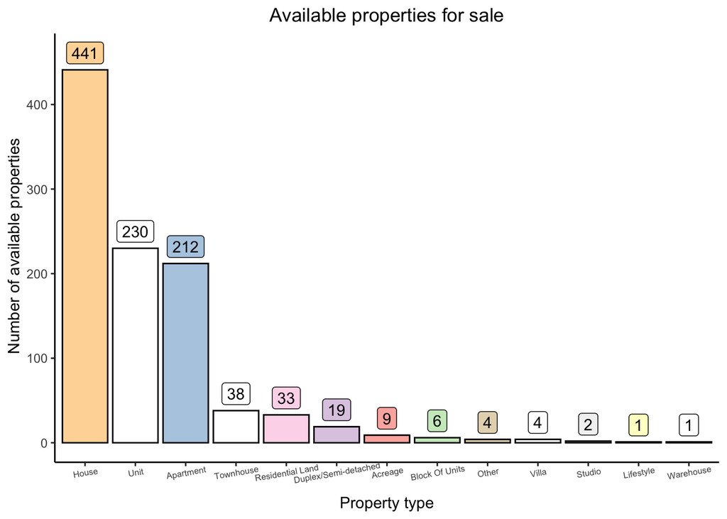

Figure 3.1: Distribution of property types up for sale

```r
df_oz_type_group <- df_oz_clean %>% count(property_type)

pl1 <- ggplot(data = df_oz_type_group,aes(x = reorder(property_type,-n),y = n,fill = property_type)) +
                                   geom_col(color = 'black') + geom_label(aes(label = n),nudge_y =20) + labs(x = "Property type",y =" Number of available properties") + ggtitle("Available properties for sale") +        theme_classic() +
                                   theme(axis.text.x = element_text(angle =10, size = 6), plot.title = element_text(hjust = 0.5),legend.position = "None") +
                                   scale_fill_brewer(palette = "Pastel1")
pl1
```

Figure 3.1 illustrates that **houses are the most abundantly available in the market with 441 listed properties followed by units at 230 listings and then apartments with 212 listings. The remaining property types are observed to constitute a small portion of the available listings**.

Let us now observe how do the prices of these properties differ for each of the property types.

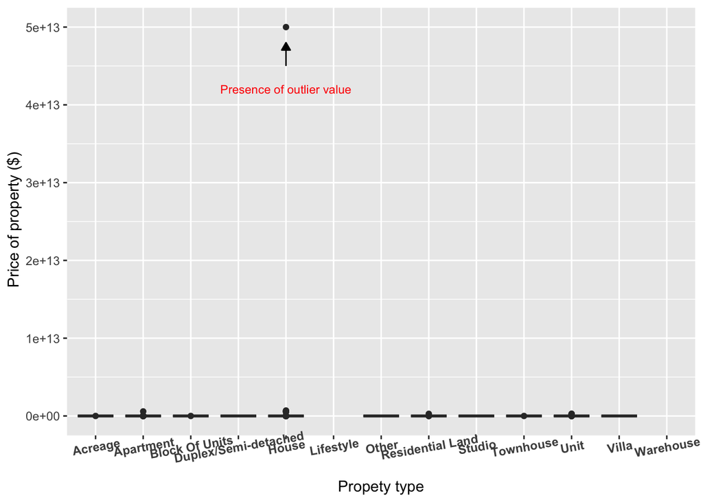

Figure 3.2: Presence of outlier values in property type

```r
pl2 <- ggplot(data = df_oz_clean, aes(x = property_type,y = price)) + geom_boxplot() +   annotate("segment",x = "House",
    y = 4.5e+13,xend = "House" ,
    yend = 4.8e+13 ,arrow = arrow(type = "closed",
                              length = unit(0.02, "npc"))
  ) +
  annotate("text",x = "House",
    y = 4.2e+13,colour = "red",
    label = 'Presence of outlier value',size = unit(3, "pt")) + theme(axis.text.x = element_text(angle = 10,face = 'bold')) + labs(x= "Propety type", y=" Price of property ($)")
pl2
```

As we can observe from figure 3.2, there is a presence of an outlier value which has completely skewed the distribution of the variables. We will replace this outlier value with a null and create a new plot for to analyse the prices for each property types.

```r
outlier <-  1.5* IQR(df_oz_clean$price, na.rm =TRUE) + quantile(df_oz_clean$price,0.75,na.rm = TRUE)
df_oz_clean <- df_oz_clean %>% mutate(new_price = if_else(price >= outlier, NA, price ))
```

After removing the outliers, let us try to visualise the plot for prices against property types.

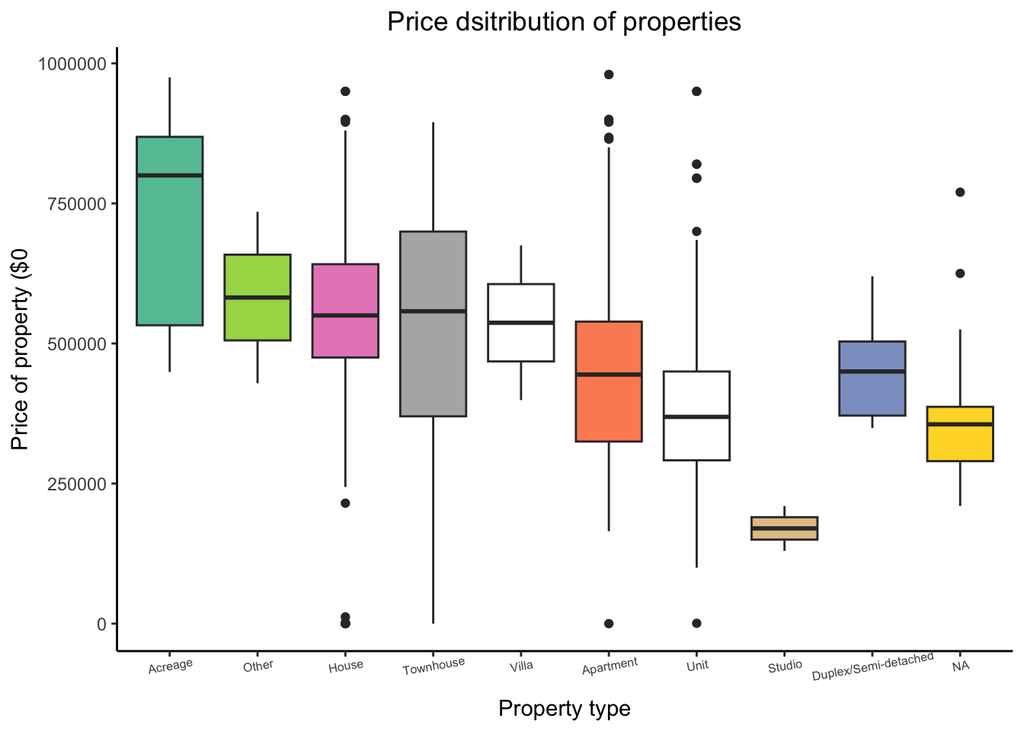

Figure 3.3: Median prices for each property type

```r
level_order <- c("Acreage","Other","House","Townhouse","Villa","Apartment","Unit","Studio","Duplex/Semi-detached")
pl3 <-
  ggplot(
    data = df_oz_clean,
    aes(x = factor(property_type,level = level_order), y = new_price, fill = property_type)) + geom_boxplot() + labs(x = "Property type",
                                                                    y ="Price of property ($0") + ggtitle("Price dsitribution of properties") +        theme_classic() +
      theme(
        axis.text.x = element_text(angle = 10, size = 6),
        plot.title = element_text(hjust = 0.5),
        legend.position = "None"
      ) +
      scale_fill_brewer(palette = "Set2")
pl3
```

Figure 3.3 illustrates the distributions of the prices for each of the property types. We can observe that Acreage properties have the highest median price while studio property types cost the least. There is a high variability observed in the reported prices for Townhouses as can be observed through the large interquartile range.

# 4 Bedroom availability

Let us look into the prices of the properties based on the number of bedrooms available in each property.

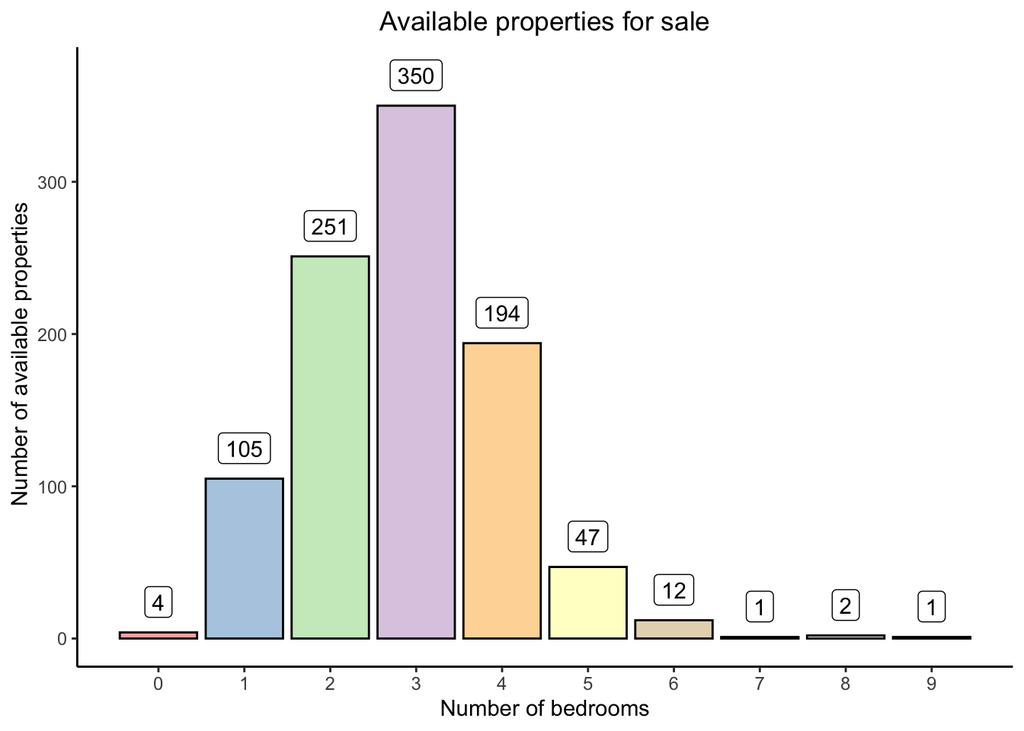

Figure 4.1: Number of properties for each bedroom count

```r
df_group_bedrooms <- df_oz_clean %>% count(bedroom_count)
pl4 <- ggplot(data = df_group_bedrooms, aes(x = bedroom_count,y = n)) + geom_col(color = 'black',aes(fill = factor(bedroom_count))) + scale_x_continuous(breaks = c(0:max(df_oz_clean$bedroom_count,na.rm = TRUE))) + geom_label(aes(label = n),nudge_y =20) + labs(x = "Number of bedrooms",y =" Number of available properties") + ggtitle("Available properties for sale") +        theme_classic() +
                                   theme(axis.text.x = element_text(size = 9), plot.title = element_text(hjust = 0.5),legend.position = "None") +
                                   scale_fill_brewer(palette = "Pastel1")
pl4
```

As we can observe from figure 4.1, **properties with 3 bedrooms are the most available for sale followed by properties with 2 bedrooms and then subsequently, properties with 4 bedrooms**.

Let us now check how do the prices differ for each bedroom count.

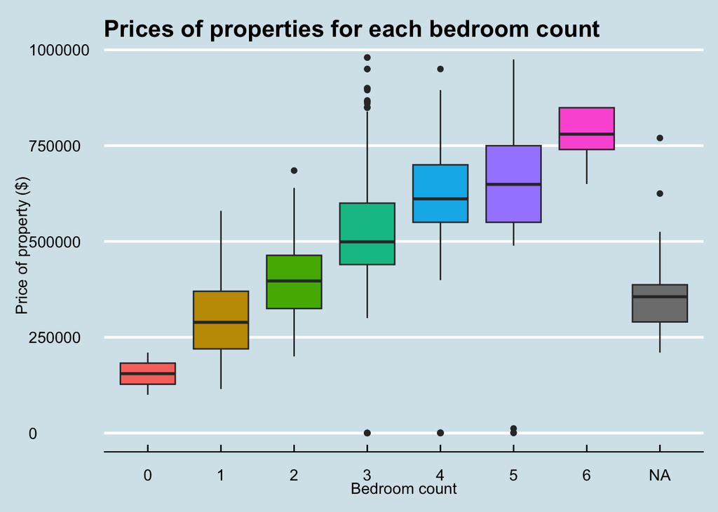

Figure 4.2: Prices of properties for each bedroom count

```r
levels <- c(0,1,2,3,4,5,6)

pl5 <- ggplot(data = df_oz_clean , aes(x = factor(bedroom_count,levels = levels),y = new_price)) + geom_boxplot(aes(fill = factor(bedroom_count))) + labs(x ="Bedroom count",y = "Price of property ($)") + theme_economist()+ theme(legend.position = 'none') + ggtitle("Prices of properties for each bedroom count")
pl5
```

As we can observe through figure 4.2, there is a steady rise in the median prices of the properties with higher counts of bedrooms. Hence, **more number of bedrooms can be associated with a higher price tag of the property.**

# 5 Bathroom availability

Let us now look into the prices of the properties based on the number of bathrooms available in each property.

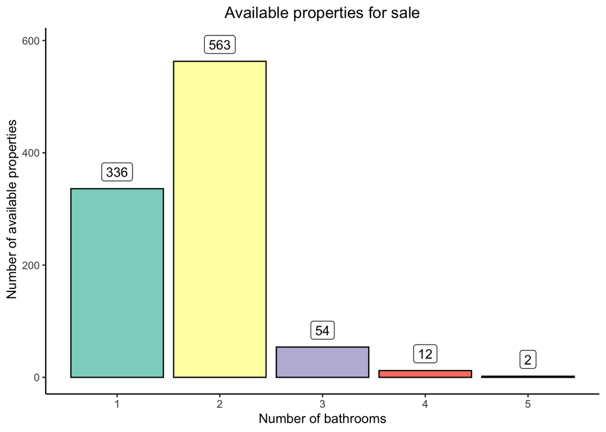

Figure 5.1: Number of properties for each bathroom count

```r
df_group_bathrooms <- df_oz_clean %>% count(bathroom_count)
pl4 <- ggplot(data = df_group_bathrooms, aes(x = bathroom_count,y = n)) + geom_col(color = 'black',aes(fill = factor(bathroom_count))) + scale_x_continuous(breaks = c(0:max(df_oz_clean$bathroom_count,na.rm = TRUE))) + geom_label(aes(label = n),nudge_y = 30) + labs(x = "Number of bathrooms",y =" Number of available properties") + ggtitle("Available properties for sale") +        theme_classic() +
                                   theme(axis.text.x = element_text(size = 9), plot.title = element_text(hjust = 0.5),legend.position = "None") +
                                   scale_fill_brewer(palette = "Set3")
pl4
```

As we can observe from figure 5.1, most properties which are up for sale have either 1 or 2 bathrooms. Majority of the properties have 2 bathrooms with 563 listings followed by 1 bathroom with 336 listings. Properties with bathrooms higher than 2 constitute a small portion of the total available listings.

Let us now visualise how do the prices for the properties vary with higher bathroom counts.

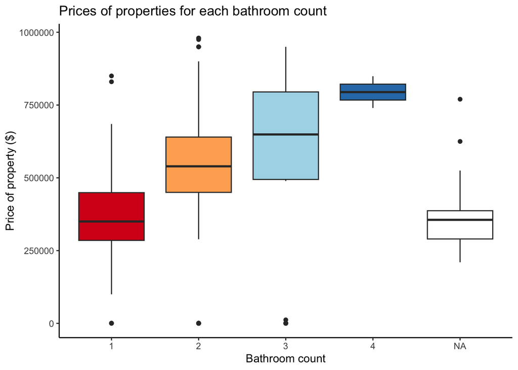

Figure 5.2: Prices of properties for each bathroom count

```r
levels <- c(0,1,2,3,4)

pl6 <- ggplot(data = df_oz_clean , aes(x = factor(bathroom_count,levels = levels),y = new_price)) + geom_boxplot(aes(fill = factor(bathroom_count))) + labs(x ="Bathroom count",y = "Price of property ($)") + theme_classic()+ theme(legend.position = 'none') + ggtitle("Prices of properties for each bathroom count") + scale_fill_brewer(palette = "RdYlBu")
pl6
```

Similar to what was observed for the relation between prices of bedrooms and the property, the properties associated with **higher bathroom counts are also observed to report higher property prices”**.

# 6 Parking space count

Another important factor to consider is the parking space associated for each of these properties. Let us now visualise the distribution of these parking spaces.

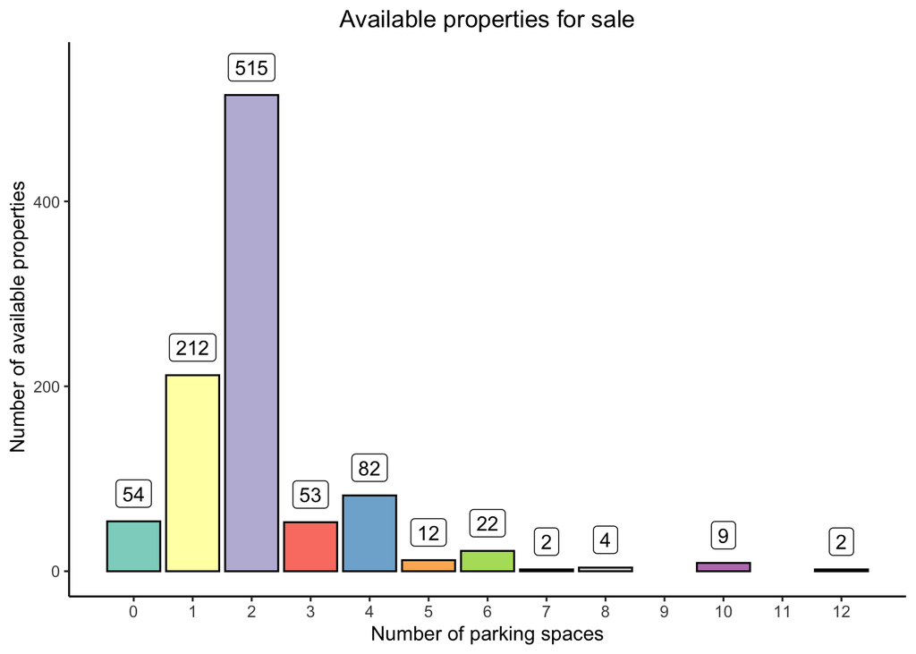

Figure 6.1: Number of properties for each parking space count

```r
df_group_park <- df_oz_clean %>% count(parking_count)

pl7 <- ggplot(data = df_group_park, aes(x = parking_count,y = n)) + geom_col(color = 'black',aes(fill = factor(parking_count))) + scale_x_continuous(breaks = c(0:max(df_oz_clean$parking_count,na.rm = TRUE))) + geom_label(aes(label = n),nudge_y = 30) + labs(x = "Number of parking spaces",y =" Number of available properties") + ggtitle("Available properties for sale") +        theme_classic() +
                                   theme(axis.text.x = element_text(size = 9), plot.title = element_text(hjust = 0.5),legend.position = "None") +
                                   scale_fill_brewer(palette = "Set3")
pl7
```

As illustrated by figure 6.1, properties with 2 parking space counts are the most widely available among the listings. Properties with parking space counts higher than 2 constitute a small part of the entire population of listings.

However, as we can observe, since there are no properties with parking spaces of 9 and 11, they do not appear in the barplot. We use an alternative dot chart (or lollipop chart) to visualise the same data as illustrated by 6.2

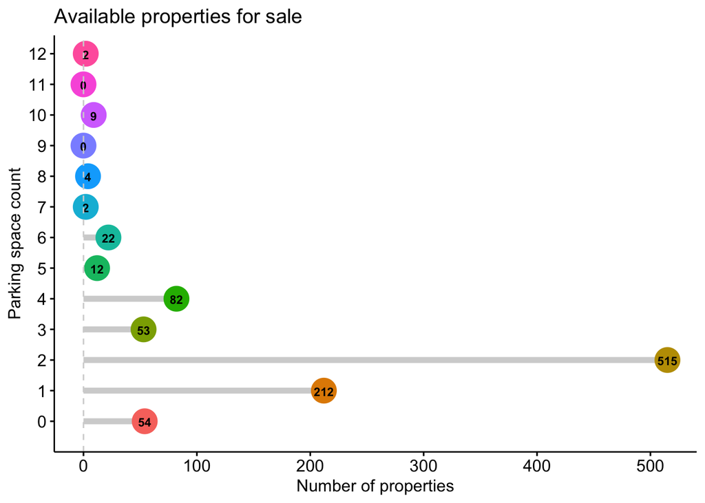

Figure 6.2: Number of properties for each parking space count

```r
level_orders <- c(0:12)

data_group_park_new <- data.frame()

data_group_park_new<- as.data.frame(c(0:12))
data_group_park_new <- data_group_park_new %>% rename("Parking_count" = "c(0:12)")

data_group_park_new <- data_group_park_new %>% left_join(df_group_park, by = c("Parking_count" = "parking_count"))
data_group_park_new$n <- data_group_park_new$n %>% replace_na(0)

ggdotchart(data_group_park_new, x = "Parking_count",
           y = "n",
           color = "Parking_count",
           add = "segments",
           add.params = list(color = "lightgray", size = 2),
           dot.size = 8,
           rotate=TRUE,
           group = "Parking_count",
           label = round(data_group_park_new$n,1),
           font.label = list(color = "black", size = 9,
                             vjust = -3, face = 'bold'),
           ggtheme = theme_pubr()
           ) + theme(legend.position = "none") +
  geom_hline(yintercept = 0, linetype = 2, color = "lightgray") + labs(y = "Number of properties", x= "Parking space count") + ggtitle("Available properties for sale")
```

We shall now visualise how do the prices of the properties differ with an increase in parking space count.

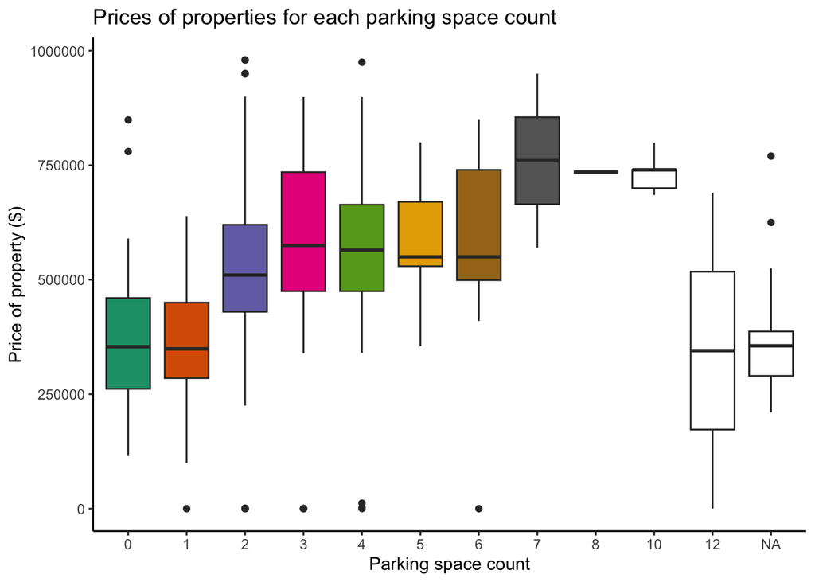

Figure 6.3: Prices of properties for each parking space count

```r
levels <- c(0,1,2,3,4)

pl8 <- ggplot(data = df_oz_clean , aes(x = factor(parking_count),y = new_price)) + geom_boxplot(aes(fill = factor(parking_count))) + labs(x ="Parking space count",y = "Price of property ($)") + theme_classic()+ theme(legend.position = 'none') + ggtitle("Prices of properties for each parking space count") + scale_fill_brewer(palette = "Dark2")
pl8
```

As illustrated by figure 6.3, **there is a gradual increase in the median prices of the properties as the available parking space counts increase**. However, there appears to be an outlier in the above analysis as the property with parking space counts of 12 are observed to report lower price as compared to properties with lower values of parking space counts. However, this could be attributed to the low population of properties with 12 parking space counts.

# 7 Correlation plot

After performing a detailed exploratory data analysis, let us study how each of these variables correlate to the prices for the housing properties. This can be visualised by using a correlation plot.

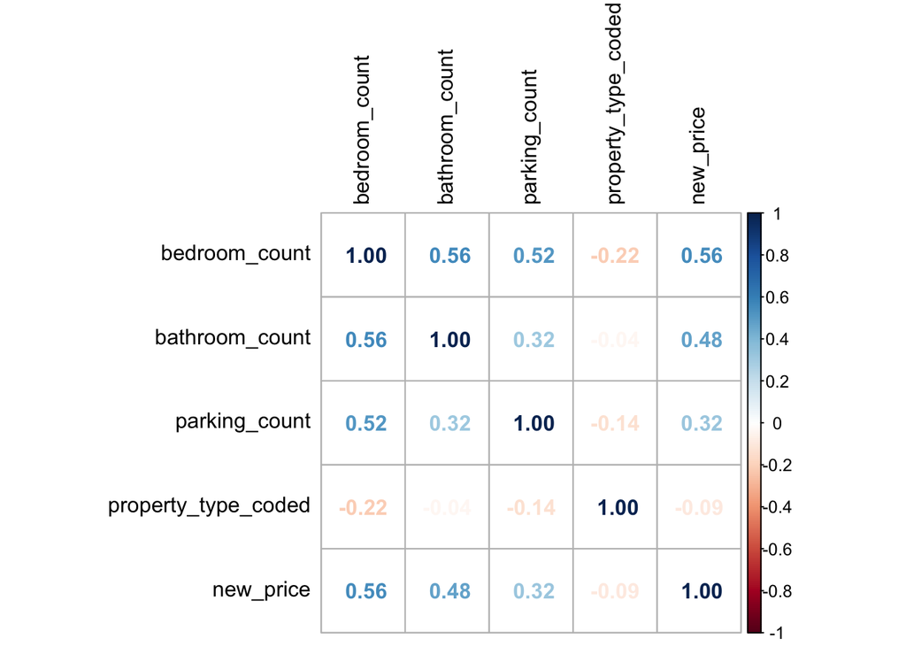

```r
df_oz_num <- df_oz_clean %>% select(c("property_type","building_size","land_size","preferred_size","bedroom_count","bathroom_count","parking_count","new_price"))
df_oz_num$property_type <- factor(df_oz_num$property_type)

df_oz_num <- df_oz_num %>% mutate(property_type_coded = case_match(property_type,
                                                                                 "House"~1,
                                                                                 "Apartment"~2,
                                                                                 "Unit" ~ 3,
                                                                                 "Studio"~4,
                                                                                 "Residential Land"~5,
                                                                                 "Block Of Units"~6,
                                                                                 "Townhouse"~7,
                                                                                 "Acreage"~8,
                                                                                 "Duplex/Semi-detached"~9,
                                                                                 "Other"~10,
                                                                                 "Villa"~11,
                                                                                 "Warehouse"~12,
                                                                                 "Lifestyle"~13
                                                                                 ))

df_oz_num <- df_oz_num %>%  select(c("bedroom_count","bathroom_count","parking_count","property_type_coded","new_price")) %>% drop_na()


corrplot(cor(df_oz_num),        # Correlation matrix
         method = "number", # Correlation plot method
         type = "full",    # Correlation plot style (also "upper" and "lower")
         diag = TRUE,      # If TRUE (default), adds the diagonal
         tl.col = "black", # Labels color
         bg = "white",     # Background color
         title = "",       # Main title
         col = NULL)
```

As we can observe from the correlation plot, there is **about 56% correlation between the number of bedrooms and the price of the property, followed by bathroom counts with 48% correlation and 32% for parking count.**